# Occupancy example walkthrough

Rob Cooke & Nick Isaac

12/05/2023

# Overview of notebook

This notebook will walkthrough preparing data (from [NBN Atlas](https://nbnatlas.org/)) and building an occupancy model for [*Lasius niger*](https://www.bwars.com/ant/formicidae/formicinae/lasius-niger) (Small Black Ant) across the UK. Although the model will be built for a single species we will use the target-group approach for the detection model and therefore we will use records for all Formicidae (Ants).

# Set-up environment

Here we load the necessary packages

```r
# # install JAGS in terminal
# sudo apt install jags

# # sparta package from github
# remotes::install_github("BiologicalRecordsCentre/sparta")

# # BRCmap package from github
# remotes::install_github("colinharrower/BRCmap")

# load necessary packages
library(sparta)
library(dplyr)
library(R2jags)
library(BRCmap)

# all other packages are called directly; other packages needed:
# readr, skimr, janitor, stringr, DT, tibble, ggplot2

# global parameters
first_year <- 1970
last_year <- 2023
focal_taxa <- "Lasius niger"

# load_rdata function
# loads an RData file, and assigns it to an object name
load_rdata <- function(fileName) {
  load(fileName)
  get(ls()[ls() != "fileName"])
}

# check where project is located
xfun::proj_root()
```

# Raw data

Download data for *Formicidae* (Ants) from [NBN Atlas](https://nbnatlas.org/)

N.B. you need to be logged in to your NBN Atlas account to be able to download data

We excluded records with ‘unconfirmed identifications’ and ‘fossil records’

Load raw downloaded data (downloaded Mon May 15 15:12:40 UTC 2023)

Data is licensed by CC-BY-NC, CC-BY, CC0 or OGL, see the [NBN Licences page](https://docs.nbnatlas.org/data-licenses/) for more details

```r
# original raw records
recs_raw_orig <- readr::read_csv("data/raw/formicidae_records-2023-05-15.csv", col_types = list(`Abundance scale` = readr::col_skip())) # readr performs safer data reading (e.g., dates are read as dates, strings are read as character)
# skip Abundance scale column which is problematic

# overview of data and columns
skimr::skim(recs_raw_orig) %>%
  dplyr::select(skim_type, skim_variable, n_missing)
```

```
── Data Summary ────────────────────────
                           Values
Name                       recs_raw_orig
Number of rows             43237
Number of columns          55
_______________________
Column type frequency:
  character                47
  Date                     2
  logical                  1
  numeric                  5
________________________
Group variables            None
```

|  | skim_variable | n_missing |
| --- | --- | --- |
| 1 | NBN Atlas record ID | 0 |
| 2 | Occurrence ID | 0 |
| 3 | Licence | 0 |
| 4 | Rightsholder | 245 |
| 5 | Scientific name | 0 |
| 6 | Taxon author | 1078 |
| 7 | Name qualifier | 42095 |
| 8 | Common name | 17785 |
| 9 | Species ID (TVK) | 0 |
| 10 | Taxon Rank | 0 |

[output cut: 37 more lines]

|  | skim_variable | n_missing |
| --- | --- | --- |
| 1 | Start date | 3546 |
| 2 | End date | 41886 |

|  | skim_variable | n_missing |
| --- | --- | --- |
| 1 | Verbatim depth | 43237 |

|  | skim_variable | n_missing |
| --- | --- | --- |
| 1 | Start date year | 213 |
| 2 | End date year | 41076 |
| 3 | Latitude (WGS84) | 205 |
| 4 | Longitude (WGS84) | 205 |
| 5 | Coordinate uncertainty (m) | 236 |

```r
# tidy data
recs <- recs_raw_orig %>%
  # tidy column names
  janitor::clean_names() %>%
  # only species-level records
  dplyr::filter(taxon_rank == "species") %>%
  # only records recorded to day precision
  dplyr::filter(!is.na(start_date)) %>%
  dplyr::filter(is.na(end_date)) %>%
  # only records recorded to 4-figure grid ref (1km)
  dplyr::filter(!is.na(osgr_1km)) %>%
  # get year from date
  dplyr::mutate(year = as.numeric(format(start_date, "%Y"))) %>%
  # temporal window
  dplyr::filter(year >= first_year & year <= last_year) %>%
  # remove duplicates
  dplyr::distinct(scientific_name, start_date, osgr_1km, year)

# number of records after cleaning
nrow(recs)
```

```
[1] 18749
```

```r
# number of records for Lasius niger
foc_recs <- dplyr::filter(recs, scientific_name == focal_taxa)
nrow(foc_recs)
```

```
[1] 2818
```

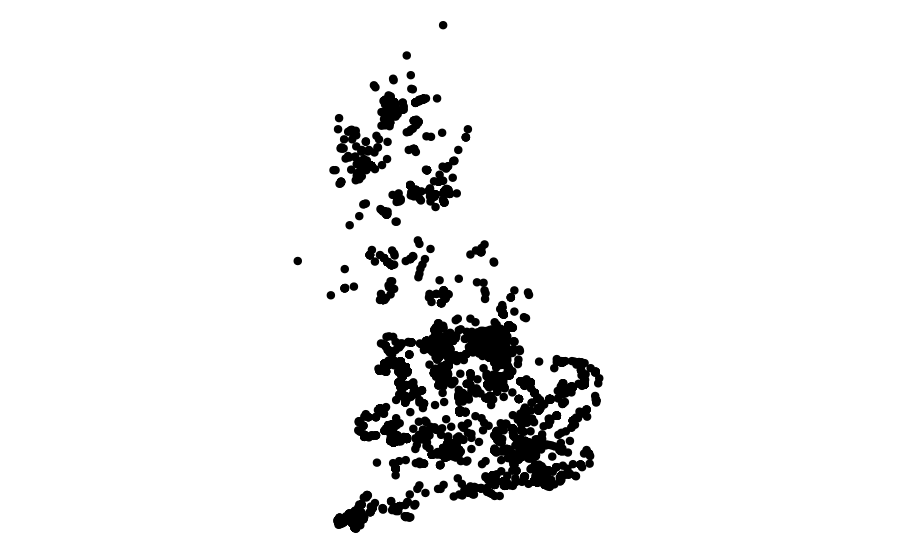

```r
# convert grid references to easting and northing
grcoord <- suppressWarnings(BRCmap::gr2sp_points(foc_recs$osgr_1km)) %>%
  as.data.frame(.)

# join easting and northing to data
foc_recs_gr <- dplyr::left_join(foc_recs, grcoord, by = c("osgr_1km" = "GRIDREF")) %>%
  # convert eastings and northings to longitude and latitude
  dplyr::mutate(latitude = BRCmap::OSGridstoLatLong(.$EASTING, .$NORTHING)[[1]],
                longitude = BRCmap::OSGridstoLatLong(.$EASTING, .$NORTHING)[[2]]) %>%
  # suppress warning about many to many
  suppressWarnings(.)

# simple ggplot of records for Lasius niger
simple_map <- ggplot2::ggplot(data = foc_recs_gr, ggplot2::aes(x = EASTING, y = NORTHING)) +
  # add points
  ggplot2::geom_point() +
  ggplot2::coord_equal() +
  ggplot2::theme_void()

# display simple_map
simple_map
```

```r
leaflet_map <- leaflet::leaflet(data = foc_recs_gr) %>%
  # default basemap
  leaflet::addTiles() %>%
  # identify columns in dataframe containing coords
  leaflet::addCircleMarkers(lng = ~longitude, lat = ~latitude)

# display leaflet_map
leaflet_map
```

[interactive chart not shown]

```r
NA
```

## Data diagnostics

Run some data diagnostics within sparta

The plot produced shows the number of records for each year in the top plot and the average list length in a box plot at the bottom. List length is the number of taxa observed on a visit to a site, where a visit is taken to be a unique combination of ‘where’ and ‘when’. A trend in the number of observations across time is not uncommon and a formal test for such a trend is performed in the form of a linear model. Trends in the number of records over time are handled by all of the methods presented in sparta in a variety of different ways. A trend in list length can cause some methods such as the reporting rate methods to fail (see ‘LessEffortPerVisit’ scenario in [Isaac et al. (2014)](https://doi.org/10.1111/2041-210X.12254)

```
## Linear model outputs ##

There is a significant change in the number of records over time:

                Estimate  Std. Error   t value     Pr(>|t|)
(Intercept) -31953.63215 3332.206290 -9.589332 4.334168e-13
time_period     16.17873    1.668973  9.693824 3.008554e-13


There is a significant change in list lengths over time:

               Estimate   Std. Error   z value     Pr(>|z|)
(Intercept) 10.13833224 1.4406108433  7.037523 1.956870e-12
time_period -0.00482882 0.0007171222 -6.733609 1.655057e-11
```

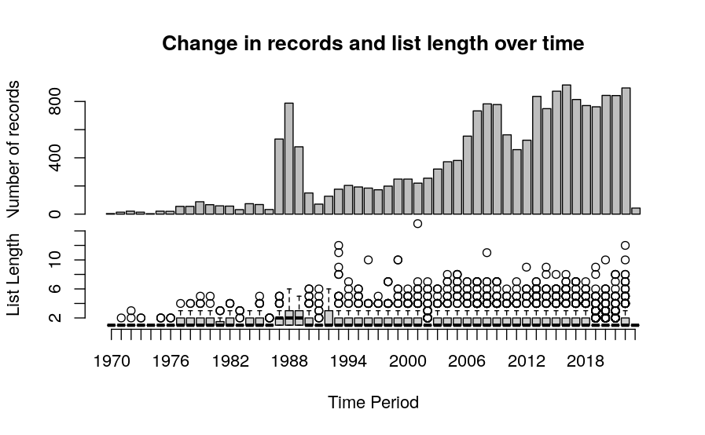

```r
# run data diagnostics - time period is year
dd <- sparta::dataDiagnostics(taxa = recs$scientific_name,
                              site = recs$osgr_1km,
                              time_period = recs$year,
                              progress_bar = FALSE)
```

# Format the data for sparta

Here we format the data to match the structure needed to run a ‘sparta’ occupancy model

```r
vis_data <- sparta::formatOccData(taxa = recs$scientific_name,
                                  site = recs$osgr_1km,
                                  survey = recs$start_date)

# saveRDS(vis_data, "data/processed/vis_data_Ants.rds")

# summary of structure of vis_data
skimr::skim(vis_data) %>%
  # remove unnecessary columns
  dplyr::select(-n_missing, -complete_rate, -character.min, -character.max, -character.empty, -character.n_unique, -character.whitespace)
```

```
── Data Summary ────────────────────────
                           Values
Name                       vis_data
Number of rows             13000
Number of columns          57
_______________________
Column type frequency:
  character                3
  logical                  52
  numeric                  2
________________________
Group variables            None
```

|  | skim_variable | mean | count |
| --- | --- | --- | --- |
| 1 | spp_vis.Crematogaster.scutellaris | 7.692308e-05 | FAL: 12999, TRU: 1 |
| 2 | spp_vis.Formica.aquilonia | 1.576923e-02 | FAL: 12795, TRU: 205 |
| 3 | spp_vis.Formica.cunicularia | 2.107692e-02 | FAL: 12726, TRU: 274 |
| 4 | spp_vis.Formica.exsecta | 1.353846e-02 | FAL: 12824, TRU: 176 |
| 5 | spp_vis.Formica.fusca | 7.507692e-02 | FAL: 12024, TRU: 976 |
| 6 | spp_vis.Formica.lemani | 1.096923e-01 | FAL: 11574, TRU: 1426 |
| 7 | spp_vis.Formica.lugubris | 5.207692e-02 | FAL: 12323, TRU: 677 |
| 8 | spp_vis.Formica.picea | 2.692308e-03 | FAL: 12965, TRU: 35 |
| 9 | spp_vis.Formica.rufa | 5.530769e-02 | FAL: 12281, TRU: 719 |
| 10 | spp_vis.Formica.rufibarbis | 3.076923e-04 | FAL: 12996, TRU: 4 |

[output cut: 42 more lines]

|  | skim_variable | mean | sd | p0 | p25 | p50 | p75 | p100 | hist |
| --- | --- | --- | --- | --- | --- | --- | --- | --- | --- |
| 1 | occDetdata.L | 1.442231 | 0.9088218 | 1 | 1 | 1 | 2 | 14 | ▇▁▁▁▁ |
| 2 | occDetdata.TP | 2008.697308 | 11.2844046 | 1970 | 2003 | 2012 | 2017 | 2023 | ▁▂▂▅▇ |

```r
# view components of vis_data

## spp_vis
head(vis_data$spp_vis)
```

|  | visit | Crematogaster scutellaris | Formica aquilonia | Formica cunicularia | Formica exsecta | Formica fusca | Formica lemani | Formica lugubris | Formica picea | Formica rufa | Formica rufibarbis | Formica sanguinea | Formicoxenus nitidulus | Hypoponera punctatissima | Lasius alienus | Lasius brunneus | Lasius emarginatus | Lasius flavus | Lasius fuliginosus | Lasius meridionalis | Lasius mixtus | Lasius neglectus | Lasius niger | Lasius platythorax | Lasius psammophilus | Lasius sabularum | Lasius umbratus | Leptothorax acervorum | Linepithema iniquum | … |
| --- | --- | --- | --- | --- | --- | --- | --- | --- | --- | --- | --- | --- | --- | --- | --- | --- | --- | --- | --- | --- | --- | --- | --- | --- | --- | --- | --- | --- | --- | --- |
| 1 | C68312007-05-141 | FALSE | FALSE | FALSE | FALSE | FALSE | FALSE | FALSE | FALSE | FALSE | FALSE | FALSE | FALSE | FALSE | FALSE | FALSE | FALSE | FALSE | FALSE | FALSE | FALSE | FALSE | FALSE | FALSE | FALSE | FALSE | FALSE | FALSE | FALSE | … |
| 2 | C72362007-05-151 | FALSE | FALSE | FALSE | FALSE | FALSE | TRUE | FALSE | FALSE | FALSE | FALSE | FALSE | FALSE | FALSE | FALSE | FALSE | FALSE | FALSE | FALSE | FALSE | FALSE | FALSE | FALSE | FALSE | FALSE | FALSE | FALSE | FALSE | FALSE | … |
| 3 | C92422014-07-081 | FALSE | FALSE | FALSE | FALSE | FALSE | TRUE | FALSE | FALSE | FALSE | FALSE | FALSE | FALSE | FALSE | FALSE | FALSE | FALSE | FALSE | FALSE | FALSE | FALSE | FALSE | FALSE | FALSE | FALSE | FALSE | FALSE | FALSE | FALSE | … |
| 4 | C93302014-08-261 | FALSE | FALSE | FALSE | FALSE | FALSE | TRUE | FALSE | FALSE | FALSE | FALSE | FALSE | FALSE | FALSE | FALSE | FALSE | FALSE | FALSE | FALSE | FALSE | FALSE | FALSE | FALSE | FALSE | FALSE | FALSE | FALSE | FALSE | FALSE | … |
| 5 | C94322014-08-261 | FALSE | FALSE | FALSE | FALSE | FALSE | TRUE | FALSE | FALSE | FALSE | FALSE | FALSE | FALSE | FALSE | FALSE | FALSE | FALSE | FALSE | FALSE | FALSE | FALSE | FALSE | FALSE | FALSE | FALSE | FALSE | FALSE | FALSE | FALSE | … |
| 6 | C94442007-06-251 | FALSE | FALSE | FALSE | FALSE | FALSE | FALSE | FALSE | FALSE | FALSE | FALSE | FALSE | FALSE | FALSE | FALSE | FALSE | FALSE | FALSE | FALSE | FALSE | FALSE | FALSE | FALSE | FALSE | FALSE | FALSE | FALSE | FALSE | FALSE | … |

```r
## occDetdata
head(vis_data$occDetdata)
```

|  | visit | site | L | TP |
| --- | --- | --- | --- | --- |
| 1 | C68312007-05-141 | C6831 | 1 | 2007 |
| 2 | C72362007-05-151 | C7236 | 2 | 2007 |
| 4 | C92422014-07-081 | C9242 | 1 | 2014 |
| 5 | C93302014-08-261 | C9330 | 1 | 2014 |
| 6 | C94322014-08-261 | C9432 | 1 | 2014 |
| 7 | C94442007-06-251 | C9444 | 1 | 2007 |

```r
NA
```

# Run sparta occupancy model

Here we run a ‘sparta’ occupancy model

Specifically, we fit a multi-season Bayesian occupancy model to the occurrence records for each species. These models separate occupancy (the proportion of occupied 1 km grid cells) and detection into hierarchically coupled submodels to allow for imperfect detection and temporal changes in recorder intensity, which are common biases in occurrence record datasets.

We use a closure period (the temporal precision of the occupancy submodel) of one year. We therefore estimate occupancy annually between 1970 and 2023, using a separate model for each species.

The detection submodel estimates the probability of detection based on repeat visits (a visit is a unique combination of 1 km grid cell and day) within years. As the data are presence-only, we use records of other species within the same taxonomic group (the target-group approach) to infer non-detections of the focal species.

We include the number of species recorded during a visit, categorized into lists of 1, 2–3 or 4+ records, in the detection submodel to estimate sampling intensity and variability in selective reporting.

We also add a random effect (intercept) of grid cell to allow for variation in occupancy status and uneven sampling among grid cells.

For the priors, we select a random walk prior on the year effect, which enables the sharing of information between the current and previous year in the occupancy submodel - imposing an *a priori* judgement that a species’ occupancy is likely to be similar from one year to the next. We use uninformative priors for the remaining parameters within the model.

We fit occupancy models using the occDetFunc function in the sparta package, which uses a Markov Chain Monte Carlo algorithm to fit the models via JAGS.

We specify three chains, 32,000 iterations, a burn in of 30,000, and a thinning rate of six.

```r
system.time({
mod_out <- sparta::occDetFunc(taxa_name = as.character(focal_taxa),
                              occDetdata = vis_data$occDetdata,
                              spp_vis = vis_data$spp_vis,
                              write_results = TRUE,
                              output_dir = "data/processed/",
                              n_chains = 3,
                              n_iterations = 32000,
                              burnin = 30000,
                              thinning = 6,
                              nyr = 2,
                              modeltype = c('ranwalk', 'halfcauchy', 'catlistlength'),
                              provenance = "NBN Atlas Formicidae Mon May 15 15:12:40 UTC 2023. vis_data_Ants.rds",
                              return_data = FALSE,
                              seed = 842845)
})
```

```
#### PLEASE REVIEW THE BELOW ####

Your model settings: ranwalk, halfcauchy, catlistlength

Model File:

model{
 # JAGS code for SPARTA model plus random walk prior
# on the year effect of the state model + intercept + halfcauchy hyperpriors

# State model
for (i in 1:nsite){
  for (t in 1:nyear){
    z[i,t] ~ dbern(muZ[i,t])
    logit(muZ[i,t])<- a[t] + eta[i]
  }}

# State model priors
a[1] ~ dnorm(0, 0.001)
for(t in 2:nyear){
  a[t] ~ dnorm(a[t-1], tau.a)
}

tau.a <- 1/(sd.a * sd.a)
sd.a ~ dt(0, 1, 1)T(0,)

for (i in 1:nsite) {
  eta[i] ~ dnorm(0, tau2)
}

tau2 <- 1/(sigma2 * sigma2)
sigma2 ~ dt(0, 1, 1)T(0,)

# Observation model priors
for (t in 1:nyear) {
  alpha.p[t] ~ dnorm(mu.lp, tau.lp)
}

mu.lp ~ dnorm(0, 0.01)

```

[output cut: 45 more lines]

[output not shown]

```
module glm loaded
```

[output not shown]

# Investigating the model

## Model object and summary

```r
# load sparta model
mod_out <- load_rdata("data/processed/Lasius niger.rdata")

# # model code
# mod_out$model
# # The model used as provided to JAGS. Also contained is a list of fully observed variables. These are those listed in the BUGS data.

# # bugs output summary
# mod_out$BUGSoutput$summary
# # A summary table of the monitored parameters. The posterior distribution for each parameter is summaried with the mean, standard deviation, various credible intervals, a formal convergence metric (Rhat), and a measure of effective sample size (n.eff).

# data summary from model
attributes(mod_out)$metadata$analysis$summary %>%
  as.data.frame() %>%
  # view
  head(.)
```

|  | species | n_sites | n_years | n_visits | n_obs | n_species_sites | min_year_model | max_year_model | region_nobs | region_years | region_nsite |
| --- | --- | --- | --- | --- | --- | --- | --- | --- | --- | --- | --- |
| 1 | Lasius niger | 1587 | 54 | 6093 | 1387 | 617 | 1970 | 2023 | NA | NA | NA |

```r
NA
```

## Convergence

We determine convergence based on the Gelman-Rubin statistic (Rhat < 1.1)

```r
# compile rhats for species:year occupancy estimates (psi)
psi_rhats <- mod_out$BUGSoutput$summary %>%
  data.frame() %>%
  tibble::rownames_to_column("para") %>%
  dplyr::filter(stringr::str_detect(para, "psi.fs"))

# view psi_rhats
DT::datatable(dplyr::select(psi_rhats, para, mean, sd, Rhat, n.eff))
```

|  | para | mean | sd | Rhat | n.eff |
| --- | --- | --- | --- | --- | --- |
| 1 | psi.fs[1] | 0.339980812570605 | 0.0922727985473475 | 1.02397445342151 | 220 |
| 2 | psi.fs[2] | 0.338998103333327 | 0.0889970273235666 | 1.02503170551778 | 220 |
| 3 | psi.fs[3] | 0.331380529868243 | 0.0849015941655041 | 1.022241483891 | 250 |
| 4 | psi.fs[4] | 0.326645486065776 | 0.0823468789547471 | 1.02330003746738 | 240 |
| 5 | psi.fs[5] | 0.324077070138822 | 0.0797900990023814 | 1.01749145584058 | 310 |
| 6 | psi.fs[6] | 0.320886103494799 | 0.0770806354124308 | 1.01408062066121 | 290 |
| 7 | psi.fs[7] | 0.320014406340808 | 0.0736692949987561 | 1.00925073131908 | 300 |
| 8 | psi.fs[8] | 0.313716993616174 | 0.0697436347847903 | 1.00900073000895 | 290 |
| 9 | psi.fs[9] | 0.304480914436806 | 0.0679595571227019 | 1.01881739770511 | 150 |
| 10 | psi.fs[10] | 0.307097267399725 | 0.0642311497634572 | 1.02781428762354 | 96 |

[output cut: 44 more lines]

```r
# Percentage of species:year occupancy estimates (psi) that converged
signif((nrow(dplyr::filter(psi_rhats, Rhat <= 1.1)) / nrow(psi_rhats)) * 100, 2)
```

```
[1] 91
```

# Model results

Here we plot the occupancy trend for Lasius niger between 1970 and 2023 with the plot function in sparta. The uncertainty envelope is the 2.5th and 97.5th quantiles.

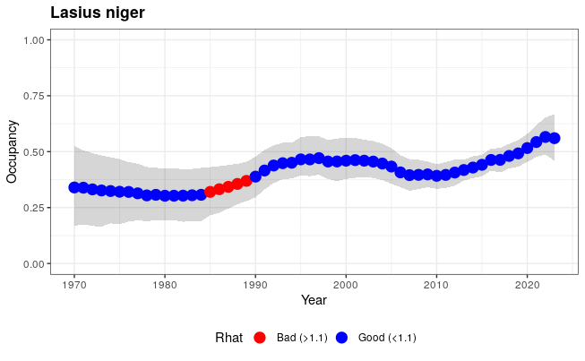

```r
# plot shows trend and rhats
plot(mod_out)
```

## Metrics of change

Here we calculate some metrics of change across the focal period

```r
# simple difference between first and last year
simp <- sparta::occurrenceChange(mod_out, firstYear = first_year, lastYear = last_year, change = "difference")

# mean, median, cis
simp[1:3]
```

```
$mean
[1] 0.2203785

$median
[1] 0.2186515

$CIs
      2.5%      97.5%
0.02706364 0.41534342
```

```r
# metric of change for 999 posterior samples
DT::datatable(simp$data)
```

|  | 1970 | 2023 | change |
| --- | --- | --- | --- |
| 1 | 0.410207939508507 | 0.603654694391934 | 0.193446754883428 |
| 2 | 0.47069943289225 | 0.560176433522369 | 0.0894770006301197 |
| 3 | 0.340894770006301 | 0.551354757403907 | 0.210459987397606 |
| 4 | 0.184625078764965 | 0.505356017643352 | 0.320730938878387 |
| 5 | 0.344675488342785 | 0.643352236925016 | 0.298676748582231 |
| 6 | 0.248267170762445 | 0.560806553245117 | 0.312539382482672 |
| 7 | 0.335223692501575 | 0.625078764965343 | 0.289855072463768 |
| 8 | 0.276622558286074 | 0.57403906742281 | 0.297416509136736 |
| 9 | 0.359168241965974 | 0.609955891619408 | 0.250787649653434 |
| 10 | 0.412098298676749 | 0.601134215500945 | 0.189035916824197 |

[output cut: 989 more lines]

```r
# percentage difference between first and last year
perc <- sparta::occurrenceChange(mod_out, firstYear = first_year, lastYear = last_year, change = "percentdif")

# mean, median, cis
perc[1:3]
```

```
$mean
[1] 80.38796

$median
[1] 62.56158

$CIs
      2.5%      97.5%
  5.397807 234.842025
```

```r
# metric of change for 999 posterior samples
DT::datatable(perc$data)
```

|  | 1970 | 2023 | change |
| --- | --- | --- | --- |
| 1 | 0.410207939508507 | 0.603654694391934 | 47.1582181259601 |
| 2 | 0.47069943289225 | 0.560176433522369 | 19.0093708165997 |
| 3 | 0.340894770006301 | 0.551354757403907 | 61.7375231053604 |
| 4 | 0.184625078764965 | 0.505356017643352 | 173.720136518771 |
| 5 | 0.344675488342785 | 0.643352236925016 | 86.654478976234 |
| 6 | 0.248267170762445 | 0.560806553245117 | 125.888324873096 |
| 7 | 0.335223692501575 | 0.625078764965343 | 86.4661654135338 |
| 8 | 0.276622558286074 | 0.57403906742281 | 107.51708428246 |
| 9 | 0.359168241965974 | 0.609955891619408 | 69.8245614035088 |
| 10 | 0.412098298676749 | 0.601134215500945 | 45.8715596330275 |

[output cut: 989 more lines]

```r
# annual growth rate between first and last year
grow <- sparta::occurrenceChange(mod_out, firstYear = first_year, lastYear = last_year, change = "growthrate")

# mean, median, cis
grow[1:3]
```

```
$mean
[1] 0.9997801

$median
[1] 0.9038504

$CIs
      2.5%      97.5%
0.09740158 2.26316972
```

```r
# metric of change for 999 posterior samples
DT::datatable(grow$data)
```

|  | 1970 | 2023 | change |
| --- | --- | --- | --- |
| 1 | 0.410207939508507 | 0.603654694391934 | 0.718006385527992 |
| 2 | 0.47069943289225 | 0.560176433522369 | 0.322801460195277 |
| 3 | 0.340894770006301 | 0.551354757403907 | 0.894354566481148 |
| 4 | 0.184625078764965 | 0.505356017643352 | 1.88219032317252 |
| 5 | 0.344675488342785 | 0.643352236925016 | 1.16242465030392 |
| 6 | 0.248267170762445 | 0.560806553245117 | 1.52046273082018 |
| 7 | 0.335223692501575 | 0.625078764965343 | 1.16053368411024 |
| 8 | 0.276622558286074 | 0.57403906742281 | 1.36111230605254 |
| 9 | 0.359168241965974 | 0.609955891619408 | 0.985557771515722 |
| 10 | 0.412098298676749 | 0.601134215500945 | 0.701628328853299 |

[output cut: 989 more lines]

```r
# linear growth rate between first and last year
lin <- sparta::occurrenceChange(mod_out, firstYear = first_year, lastYear = last_year, change = "lineargrowth")

# mean, median, cis
lin[1:3]
```

```
$mean
[1] 0.7431407

$median
[1] 0.6505543

$CIs
     2.5%     97.5%
0.1077112 1.7144210
```

```r
# metric of change for 999 posterior samples
DT::datatable(lin$data)
```

|  | 1970 | 2023 | change |
| --- | --- | --- | --- |
| 1 | 0.35915133026135 | 0.501409370117309 | 0.39609498244776 |
| 2 | 0.383539659723349 | 0.491389943853077 | 0.281197214930841 |
| 3 | 0.314356750682939 | 0.519993788320605 | 0.654151810613009 |
| 4 | 0.214781418975579 | 0.537739209885997 | 1.50365796282936 |
| 5 | 0.258527432747905 | 0.564894524312882 | 1.18504674072141 |
| 6 | 0.237505708756847 | 0.527574489708891 | 1.22131287904751 |
| 7 | 0.31052459152107 | 0.493185080706961 | 0.588231960280984 |
| 8 | 0.269885132692967 | 0.51796136344412 | 0.919191910557648 |
| 9 | 0.294937743900313 | 0.505228883766455 | 0.713001791785656 |
| 10 | 0.367440092287763 | 0.467848680088015 | 0.273265193177711 |

[output cut: 989 more lines]

```r
# last 10 years

# percentage difference for last 10 years
perc_10yr <- sparta::occurrenceChange(mod_out, firstYear = last_year - 10, lastYear = last_year, change = "percentdif")

# mean, median, cis
perc_10yr[1:3]
```

```
$mean
[1] 34.50881

$median
[1] 33.62319

$CIs
     2.5%     97.5%
 8.222091 66.304257
```

```r
# annual growth rate for last 10 years
grow_10yr <- sparta::occurrenceChange(mod_out, firstYear = last_year - 10, lastYear = last_year, change = "growthrate")

# mean, median, cis
grow_10yr[1:3]
```

```
$mean
[1] 2.679598

$median
[1] 2.670057

$CIs
     2.5%     97.5%
0.7209058 4.7326526
```

# Resources

**Going further:**  
Multi-species indicators (see [BRC indicators package](https://github.com/BiologicalRecordsCentre/BRCindicators))

Species richness, species trends, temporal beta diversity (see [Protected Areas GitHub repository](https://github.com/03rcooke/pa_occ))

Running code on HPC (e.g., JASMIN) (see [Protected Areas GitHub repository](https://github.com/03rcooke/pa_occ))

ROBITT assessment (see [Protected Areas GitHub repository](https://github.com/03rcooke/pa_occ)), including use of occAssess ([occAssess GitHub repository](https://github.com/robboyd/occAssess))  
**Useful papers for sparta-style occupancy models:**  
Isaac, N.J., van Strien, A.J., August, T.A., de Zeeuw, M.P. and Roy, D.B., 2014. [Statistics for citizen science: extracting signals of change from noisy ecological data](https://doi.org/10.1111/2041-210X.12254), pp.1052-1060.

Outhwaite, C.L., Chandler, R.E., Powney, G.D., Collen, B., Gregory, R.D. and Isaac, N.J., 2018. [Prior specification in Bayesian occupancy modelling improves analysis of species occurrence data](https://doi.org/10.1016/j.ecolind.2018.05.010). Ecological Indicators, 93, pp.333-343.

Outhwaite, C.L., Powney, G.D., August, T.A., Chandler, R.E., Rorke, S., Pescott, O.L., Harvey, M., Roy, H.E., Fox, R., Roy, D.B. and Alexander, K., 2019. [Annual estimates of occupancy for bryophytes, lichens and invertebrates in the UK, 1970–2015](https://www.nature.com/articles/s41597-019-0269-1). Scientific data, 6(1), p.259.

Pocock, M.J., Logie, M.W., Isaac, N.J., Outhwaite, C.L. and August, T., 2019. [Rapid assessment of the suitability of multi-species citizen science datasets for occupancy trend analysis](https://www.biorxiv.org/content/10.1101/813626v1). bioRxiv, p.813626.

Outhwaite, C.L., Gregory, R.D., Chandler, R.E., Collen, B. and Isaac, N.J., 2020. [Complex long-term biodiversity change among invertebrates, bryophytes and lichens](https://www.nature.com/articles/s41559-020-1111-z). Nature ecology & evolution, 4(3), pp.384-392.

Cooke, R., Mancini, F., Boyd, R.J., Evans, K.L., Shaw, A., Webb, T.J. and Isaac, N.J., 2023. [Protected areas support more species than unprotected areas in Great Britain, but lose them equally rapidly](https://doi.org/10.1016/j.biocon.2022.109884). Biological Conservation, 278, p.109884.

Boyd, R.J., August, T.A., Cooke, R., Logie, M., Mancini, F., Powney, G.D., Roy, D.B., Turvey, K. and Isaac, N.J., 2023. [An operational workflow for producing periodic estimates of species occupancy at national scales](https://onlinelibrary.wiley.com/doi/full/10.1111/brv.12961). Biological Reviews.